# R statistics: A social scientist’s journey

7/15/2020

## Goals

- Describe advantages for adopting R statistical software as a social scientist
- Explore data science using two packages: `epiDisplay` & `lavaan`

## My Journey with R

- PhD. in Family Social Science (2018)
- Introduced to R in introductory statistical classes at the University of Minnesota
  - About 18 months of R
  - began and ended with `base` package
- Research work at Program in Human Sexuality
  - Sex Offender Treatmeint Intervention and Progress Scale (SOTIPS) project
  - Recidivism tool created by using Cox Hazard Regression
  - Structural Equation Modeling (SEM)

## Things that helped

- R for Data Science
  - Easy to use
  - [Available online (Grolemund & Wickham)](https://r4ds.had.co.nz)
- [Graphics Cook Book (Chang, 2020)](https://r-graphics.org)
- Stack Overflow
  - online community for developers
  - (look for your answer before posting!)
- Twitter

## Why use R?

- R is free

| Package | Stata/SE | SPSS v26 | SAS |
| --- | --- | --- | --- |
| Student | 94 | 34.95 |  |
| Business | 765 | 1,290 | 8,700 |

## Why use R?

- R is becoming popular

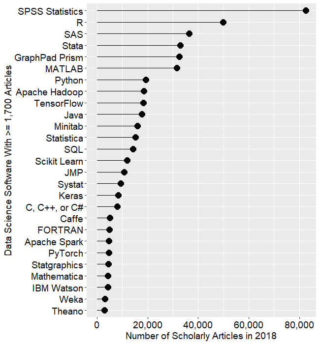

## Why use R?

- Advanced statistics (e.g., SEM)
- Better graphics

## Graphics

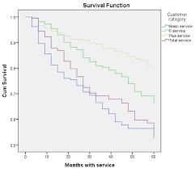

SPSS Hazard Regression

## Graphics

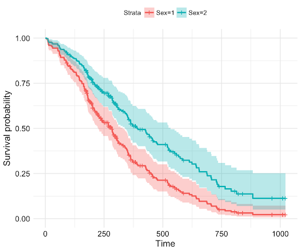

R Hazard Regression

## R package: epiDisplay

- [Virasakdi Chongsuvivatwong, 2018](https://cran.r-project.org/web/packages/epiDisplay/epiDisplay.pdf)
- Diverse package that includes data exploration and data presentation
  - Can create tables as well as graphics

## epiDisplay

```r
library(epiDisplay)
library(lavaan)
library(png)
data(Oswego)
.data <- Oswego
attach(.data)
agegr <- cut(age, breaks=c(0,10,20,30,40,50,60,70,80))
```

## epiDisplay

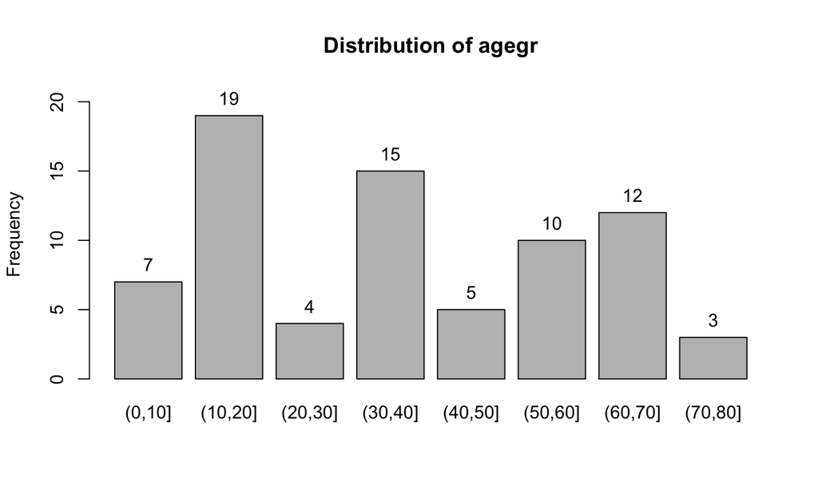

```
## agegr :
##         Frequency Percent Cum. percent
## (0,10]          7     9.3          9.3
## (10,20]        19    25.3         34.7
## (20,30]         4     5.3         40.0
## (30,40]        15    20.0         60.0
## (40,50]         5     6.7         66.7
## (50,60]        10    13.3         80.0
## (60,70]        12    16.0         96.0
## (70,80]         3     4.0        100.0
##   Total        75   100.0        100.0
```

```r
tab1(agegr, col="grey") # graphic output from older versions of 'tab1'
```

## epiDisplay

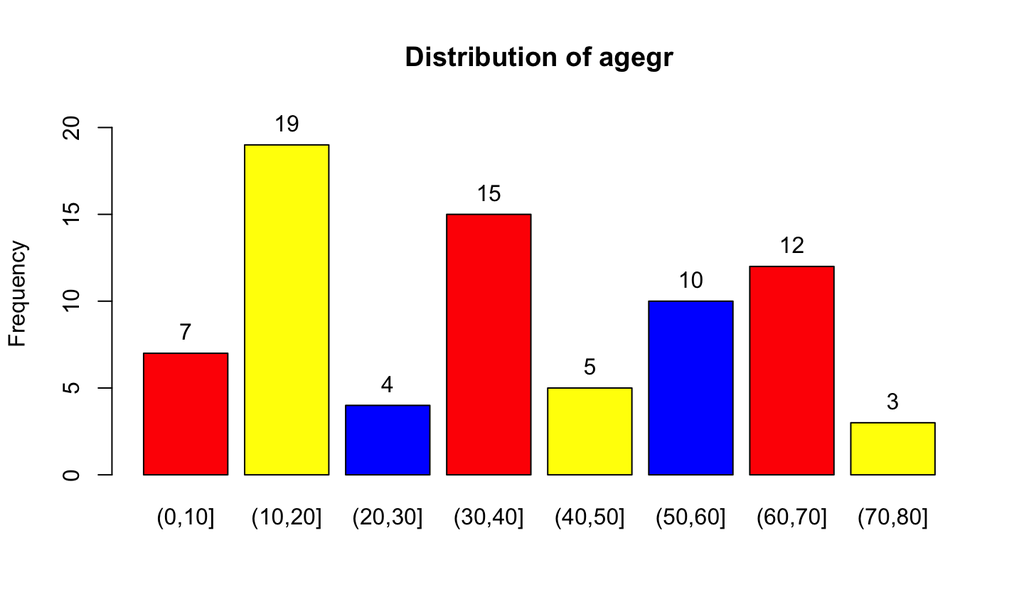

```
## agegr :
##         Frequency Percent Cum. percent
## (0,10]          7     9.3          9.3
## (10,20]        19    25.3         34.7
## (20,30]         4     5.3         40.0
## (30,40]        15    20.0         60.0
## (40,50]         5     6.7         66.7
## (50,60]        10    13.3         80.0
## (60,70]        12    16.0         96.0
## (70,80]         3     4.0        100.0
##   Total        75   100.0        100.0
```

```r
tab1(agegr, col=c("red","yellow","blue")) # Colours recycled
```

## epiDisplay

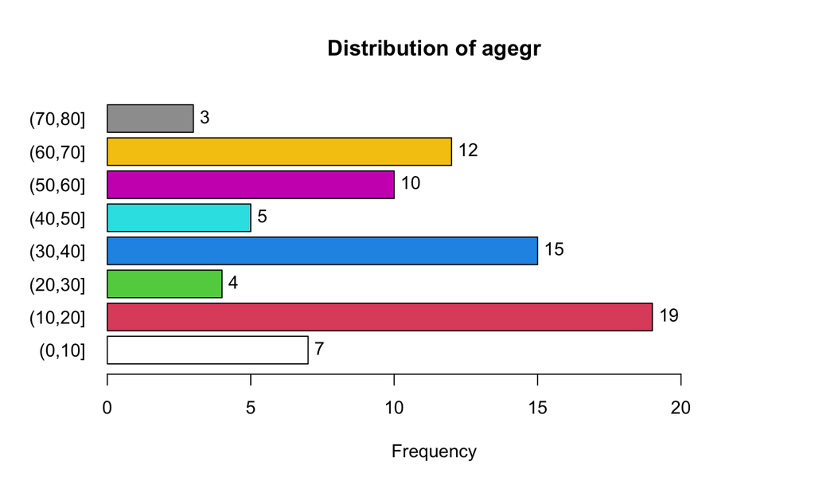

```
## agegr :
##         Frequency Percent Cum. percent
## (0,10]          7     9.3          9.3
## (10,20]        19    25.3         34.7
## (20,30]         4     5.3         40.0
## (30,40]        15    20.0         60.0
## (40,50]         5     6.7         66.7
## (50,60]        10    13.3         80.0
## (60,70]        12    16.0         96.0
## (70,80]         3     4.0        100.0
##   Total        75   100.0        100.0
```

```r
tab1(agegr, horiz=TRUE)
```

## epiDisplay

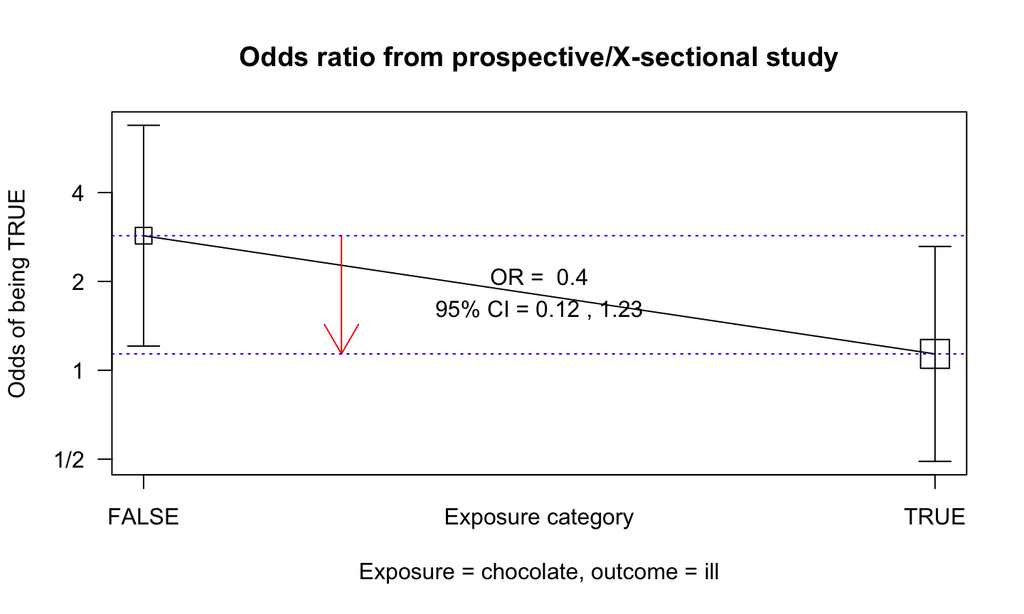

```
##
##        chocolate
## ill     FALSE TRUE Total
##   FALSE     7   22    29
##   TRUE     20   25    45
##   Total    27   47    74
##
## OR =  0.4
## 95% CI =  0.14, 1.12
## Chi-squared = 3.14, 1 d.f., P value = 0.076
## Fisher's exact test (2-sided) P value = 0.089
```

```r
cc(ill, chocolate)
```

## epiDisplay

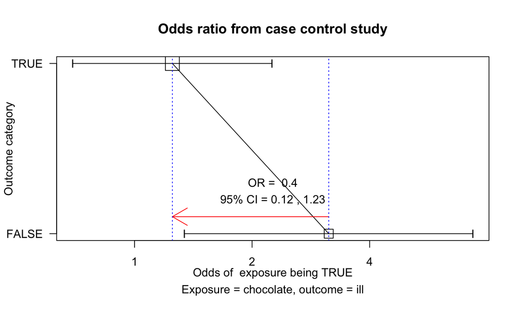

```
##
##        chocolate
## ill     FALSE TRUE Total
##   FALSE     7   22    29
##   TRUE     20   25    45
##   Total    27   47    74
##
## OR =  0.4
## 95% CI =  0.14, 1.12
## Chi-squared = 3.14, 1 d.f., P value = 0.076
## Fisher's exact test (2-sided) P value = 0.089
```

```r
cc(ill, chocolate, design="case-control")
```

## Odds Ratio

```r
cs(ill, chocolate) # The outcome variable should come first.
```

```
##
##           Exposure
## Outcome    Non-exposed Exposed Total
##   Negative 7           22      29
##   Positive 20          25      45
##   Total    27          47      74
##
##            Rne         Re      Rt
##   Risk     0.74        0.53    0.61
##                                          Estimate Lower95ci Upper95ci
##  Risk difference (Re - Rne)              -0.21    -0.42     0.01
##  Risk ratio                              0.72     0.47      1.1
##  Protective efficacy =(Rne-Re)/Rne*100   28.2     -9.85     52.81
##    or percent of risk reduced
##  Number needed to treat (NNT)            4.79     -76.39    2.4
##    or -1/(risk difference)
```

```r
#    For the following table
#          chocolate
#    ill     FALSE TRUE
#     FALSE     7   22
#     TRUE     20   25
#
```

## Odds Ratio

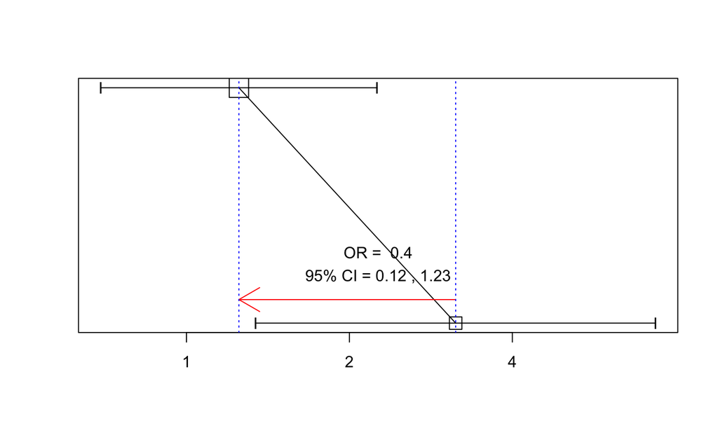

```r
graph.casecontrol(25, 22, 20, 7)
```

```r
#cci(25, 22, 20, 7)
```

## Odds Ratio

[output not shown]

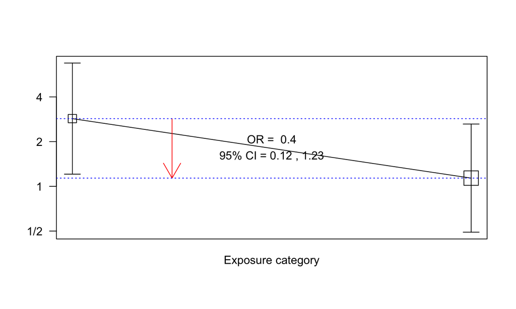

```r
graph.prospective(25, 22, 20, 7)
```

```r
# Graphs can additionally decorated
#Alternatively
# table1 <- make2x2(25,22,20,7)
# cc(outcome=NULL, exposure=NULL, cctable=table1)
# cs(outcome=NULL, exposure=NULL, cctable=table1)
# agegr <- pyramid(age, sex, bin=30)$ageGroup
# cs(ill, agegr, main="Risk ratio by age group", xlab="Age (years)")
```

## epiDisplay: Output

```r
model1 <- glm(am ~ cyl + disp, data = mtcars, family = binomial)
```

## epiDisplay: Output

```r
logistic.display(model1, crude = TRUE, crude.p.value = TRUE, decimal = 3)
```

```
##
## Logistic regression predicting am
##
##                   crude OR(95%CI)      crude P value adj. OR(95%CI)
## cyl (cont. var.)  0.501 (0.305,0.824)  0.0064        2.102 (0.514,8.604)
##
## disp (cont. var.) 0.986 (0.976,0.996)  0.0047        0.973 (0.946,1.001)
##
##                   P(Wald's test) P(LR-test)
## cyl (cont. var.)  0.3015         0.2845
##
## disp (cont. var.) 0.0558         0.0205
##
## Log-likelihood = -14.29311
## No. of observations = 32
## AIC value = 34.58622
```

## Structural Equation Modeling

- Allows for testing indirect relationships
- Path models
- Factor analysis

## Barriers to SEM with other statistical packages

- Black box regarding estimation
- Missing values in Stata

## CFA example

```r
 model <- '
  # measurement model
    ind60 =~ x1 + x2 + x3
    dem60 =~ y1 + y2 + y3 + y4
    dem65 =~ y5 + y6 + y7 + y8
  # regressions
    dem60 ~ ind60
    dem65 ~ ind60 + dem60
  # residual correlations
    y1 ~~ y5
    y2 ~~ y4 + y6
    y3 ~~ y7
    y4 ~~ y8
    y6 ~~ y8
'

fit <- sem(model, data=PoliticalDemocracy)
```

## CFA example

```r
summary(fit, standardized=TRUE)
```

```
## lavaan 0.6-6 ended normally after 68 iterations
##
##   Estimator                                         ML
##   Optimization method                           NLMINB
##   Number of free parameters                         31
##
##   Number of observations                            75
##
## Model Test User Model:
##
##   Test statistic                                38.125
##   Degrees of freedom                                35
##   P-value (Chi-square)                           0.329
##
## Parameter Estimates:
##
##   Standard errors                             Standard
##   Information                                 Expected
##   Information saturated (h1) model          Structured
##
## Latent Variables:
##                    Estimate  Std.Err  z-value  P(>|z|)   Std.lv  Std.all
##   ind60 =~
##     x1                1.000                               0.670    0.920
##     x2                2.180    0.139   15.742    0.000    1.460    0.973
##     x3                1.819    0.152   11.967    0.000    1.218    0.872
##   dem60 =~
##     y1                1.000                               2.223    0.850
##     y2                1.257    0.182    6.889    0.000    2.794    0.717
##     y3                1.058    0.151    6.987    0.000    2.351    0.722
##     y4                1.265    0.145    8.722    0.000    2.812    0.846
##   dem65 =~
##     y5                1.000                               2.103    0.808
##     y6                1.186    0.169    7.024    0.000    2.493    0.746
##     y7                1.280    0.160    8.002    0.000    2.691    0.824
##     y8                1.266    0.158    8.007    0.000    2.662    0.828
##
## Regressions:
##                    Estimate  Std.Err  z-value  P(>|z|)   Std.lv  Std.all
##   dem60 ~
```

[output cut: 20 more lines]

```
##                    Estimate  Std.Err  z-value  P(>|z|)   Std.lv  Std.all
##    .x1                0.082    0.019    4.184    0.000    0.082    0.154
##    .x2                0.120    0.070    1.718    0.086    0.120    0.053
##    .x3                0.467    0.090    5.177    0.000    0.467    0.239
##    .y1                1.891    0.444    4.256    0.000    1.891    0.277
##    .y2                7.373    1.374    5.366    0.000    7.373    0.486
##    .y3                5.067    0.952    5.324    0.000    5.067    0.478
##    .y4                3.148    0.739    4.261    0.000    3.148    0.285
##    .y5                2.351    0.480    4.895    0.000    2.351    0.347
##    .y6                4.954    0.914    5.419    0.000    4.954    0.443
##    .y7                3.431    0.713    4.814    0.000    3.431    0.322
##    .y8                3.254    0.695    4.685    0.000    3.254    0.315
##     ind60             0.448    0.087    5.173    0.000    1.000    1.000
##    .dem60             3.956    0.921    4.295    0.000    0.800    0.800
##    .dem65             0.172    0.215    0.803    0.422    0.039    0.039
```

## Advantages to Lavaan

- Easily change estimation
  - MSW; WSL
- Drawing models
  - [Sacha Epskamp](http://sachaepskamp.com/semPlot/examples)

## Path Analysis

- Anxiety, hypersexuality, compulsivity, and isolation are related to sex offending among adolescents
- In order to increase our understanding of adolescent sex offending behaviors, testing the direct and indirect effects of attachment, isolation, and hypersexuality is needed
- Newstrom, Swinburne, & Miner (2020)
  - Structural equation modeling (SEM) allows researchers to test relationships between observed and unobserved (i.e., latent) variables in order to test a theoretical model (Schumaker & Lomax, 2010).

## Path Analysis

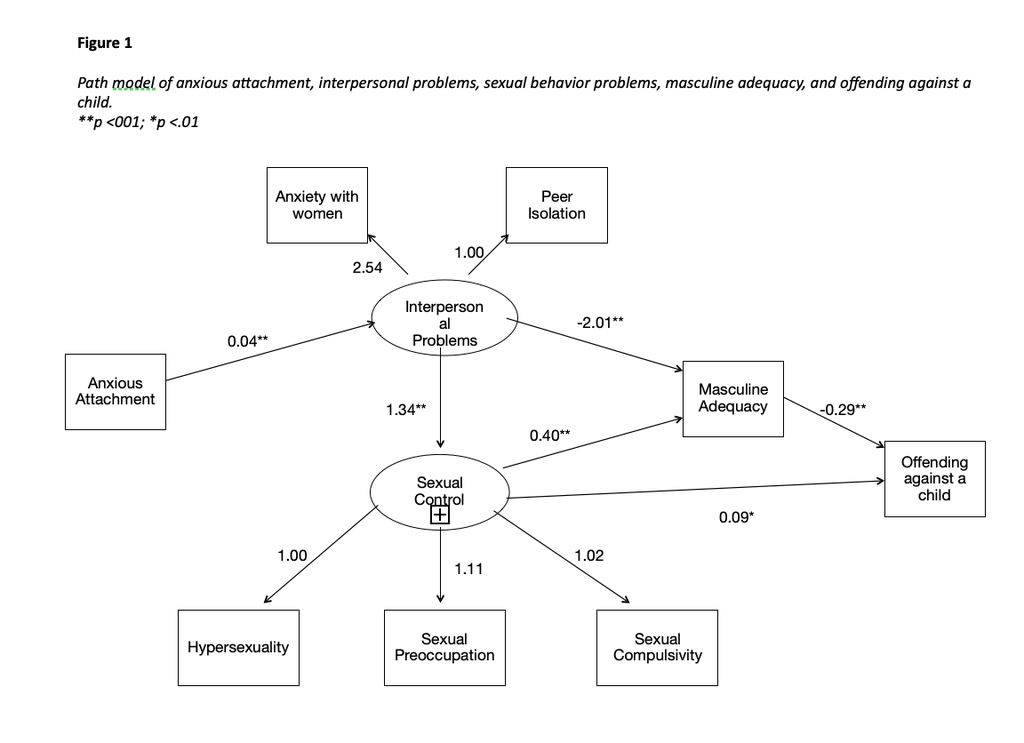

## Using R as a Researcher

[figure not shown]

## Using R as a Researcher

[figure not shown]